# Dealing with Multiple Imputations

Carles Hernandez-Ferrer and Juan R. Gonzalez

18 September 2018

#### Abstract

An introductory guide to analysing multiple imputed exposome data with R package `rexposome`. The areas covered in this document are: loading the multiple imputations of both exposures and phenotypes from common `data.frame`s, exploration the exposome data, and testing association between exposures and health outcomes.

#### Package

rexposome 1.3.3

# 1 Introduction

## 1.1 Dummy Imputation with `mice`

To illustrate how to perform a multiple imputation using `mice` we start loading both `rexposome` and `mice` libraries.

```r
library(rexposome)
library(mice)
```

The we load the `txt` files includes in `rexposome` package so we can load the exposures and see the amount of missing data (check vignette *Exposome Data Analysis* for more information).

The following lines locates where the `txt` files were installed.

```r
path <- file.path(path.package("rexposome"), "extdata")
description <- file.path(path, "description.csv")
phenotype <- file.path(path, "phenotypes.csv")
exposures <- file.path(path, "exposures.csv")
```

Once the files are located we load them as `data.frames`:

```r
dd <- read.csv(description, header=TRUE, stringsAsFactors=FALSE)
ee <- read.csv(exposures, header=TRUE)
pp <- read.csv(phenotype, header=TRUE)
```

In order to speed up the imputation process that will be carried in this vignette, we will remove four families of exposures.

```r
dd <- dd[-which(dd$Family %in% c("Phthalates", "PBDEs", "PFOAs", "Metals")), ]
ee <- ee[ , c("idnum", dd$Exposure)]
```

We can check the amount of missing data in both exposures and phenotypes `data.frames`:

```r
data.frame(
    Set=c("Exposures", "Phenotypes"),
    Count=c(sum(is.na(ee)), sum(is.na(pp)))
)
```

```
##          Set Count
## 1  Exposures   304
## 2 Phenotypes     5
```

Before running `mice`, we need to collapse both the exposures and the phenotypes in a single `data.frame`.

```r
rownames(ee) <- ee$idnum
rownames(pp) <- pp$idnum

dta <- cbind(ee[ , -1], pp[ , -1])
dta[1:3, c(1:3, 52:56)]
```

[output not shown]

Once this is done, the *class* of each column needs to be set, so `mice` will be able to differentiate between continuous and categorical exposures.

```r
for(ii in c(1:13, 18:47, 55:56)) {
    dta[, ii] <- as.numeric(dta[ , ii])
}
for(ii in c(14:17, 48:54)) {
    dta[ , ii] <- as.factor(dta[ , ii])
}
```

With this `data.frame` we perform the imputation calling `mice` functions (for more information about this call, check `mice`’s vignette). We remove the columns *birthdate* since it is not necessary for the imputations and carries lots of categories.

```r
imp <- mice(dta[ , -52], pred = quickpred(dta[ , -52], mincor = 0.2,
    minpuc = 0.4), seed = 38788, m = 5, maxit = 10, printFlag = FALSE)
class(imp)
```

```
## [1] "mids"
```

`mice` package includes the function `complete` that allows to extract a single data-set from an object of class `mids`. We will use this function to extract the sets and join them in a single `data.frame`.

If we set the argument `action` of the `complete` function to `0`, it will return the original data:

```r
me <- complete(imp, action = 0)
me[ , ".imp"] <- 0
me[ , ".id"] <- rownames(me)
dim(me)
```

```
## [1] 109  57
```

```r
summary(me[, c("H_pesticides", "Benzene")])
```

```
##  H_pesticides    Benzene
##  0   :68      Min.   :-0.47427
##  1   :35      1st Qu.:-0.19877
##  NA's: 6      Median :-0.11975
##               Mean   :-0.12995
##               3rd Qu.:-0.06879
##               Max.   : 0.13086
##               NA's   :3
```

If the `action` number is between 1 and the `m` value, it will return the selected set.

```r
for(set in 1:5) {
    im <- complete(imp, action = set)
    im[ , ".imp"] <- set
    im[ , ".id"] <- rownames(im)
    me <- rbind(me, im)
}
me <- me[ , c(".imp", ".id", colnames(me)[-(97:98)])]
rownames(me) <- 1:nrow(me)
dim(me)
```

```
## [1] 654  59
```

## 1.2 Data Format

The format of the multiple imputation data for `rexposome` needs to follow some restrictions:

1. Both the **exposures** and the **phenotypes** are stored in the same `data.frame`.
2. This `data.frame` must have a column called `.imp` indicating the number of imputation. This imputation tagged as `0` are raw exposures (no imputation).
3. This `data.frame` must have a column called `.id` indicating the name of samples. This will be converted to character.
4. A `data.frame` with the *description* with the relation between exposures and families.

## 1.3 Creating an `imExposomeSet`

With the exposome `data.frame` and the description `data.frame` an object of class `imExposomeSet` can be created. To this end, the function `loadImputed` is used:

```r
ex_imp <- loadImputed(data = me, description = dd,
                       description.famCol = "Family",
                       description.expCol = "Exposure")
```

The function `loadImputed` has several arguments:

```r
args(loadImputed)
```

```
## function (data, description, description.famCol = "family", description.expCol = "exposure",
##     exposures.asFactor = 5, warnings = TRUE)
## NULL
```

The argument `data` is filled with the `data.frame` of exposures. The argument `decription` with the `data.frame` with the exposures’ description. `description.famCol` indicates the column on the description that corresponds to the family. `description.expCol` indicates the column on the description that corresponds to the exposures. Finally, `exposures.asFactor` indicates that the exposures with less that, by default, five different values are considered categorical exposures, otherwise continuous.

```r
ex_imp
```

```
## Object of class 'imExposomeSet'
##  . exposures description:
##     . categorical:  4
##     . continuous:  43
##  . #imputations: 6 (raw detected)
##  . assayData: 47 exposures 109 individuals
##  . phenoData: 109 individuals 12 phenotypes
##  . featureData: 47 exposures 3 explanations
```

### 1.3.1 Accessing to Exposome Data

The class `ExposomeSet` has several accessors to get the data stored in it. There are four basic methods that returns the names of the individuals (`sampleNames`), the name of the exposures (`exposureNames`), the name of the families of exposures (`familyNames`) and the name of the phenotypes (`phenotypeNames`).

```r
head(sampleNames(ex_imp))
```

```
## [1] "1"   "10"  "100" "101" "102" "103"
```

```r
head(exposureNames(ex_imp))
```

```
## [1] "DDE"    "DDT"    "HCB"    "bHCH"   "PCB118" "PCB153"
```

```r
familyNames(ex_imp)
```

```
## [1] "Organochlorines"   "Bisphenol A"       "Water Pollutants"
## [4] "Cotinine"          "Home Environment"  "Air Pollutants"
## [7] "Built Environment" "Noise"             "Temperature"
```

```r
phenotypeNames(ex_imp)
```

```
##  [1] "whistling_chest" "flu"             "rhinitis"        "wheezing"
##  [5] "sex"             "age"             "cbmi"            "blood_pre"
##  [9] ".imp.1"          ".id.1"
```

`fData` will return the description of the exposures (including internal information to manage them).

```r
head(fData(ex_imp), n = 3)
```

```
## DataFrame with 3 rows and 4 columns
##              Family    Exposure                             Name       .type
##         <character> <character>                      <character> <character>
## DDE Organochlorines         DDE Dichlorodiphenyldichloroethylene     numeric
## DDT Organochlorines         DDT  Dichlorodiphenyltrichloroethane     numeric
## HCB Organochlorines         HCB                Hexachlorobenzene     numeric
```

`pData` will return the phenotypes information.

```r
head(pData(ex_imp), n = 3)
```

```
## DataFrame with 3 rows and 12 columns
##        .imp         .id whistling_chest      flu rhinitis wheezing      sex
##   <numeric> <character>        <factor> <factor> <factor> <factor> <factor>
## 1         0           1           never       no       no       no     male
## 2         0          10         1-2 epi      yes       no       no     male
## 3         0         100           never       no       no       no     male
##        age      cbmi blood_pre    .imp.1       .id.1
##   <factor> <numeric> <numeric> <numeric> <character>
## 1      4.2      16.3       120         0           1
## 2      4.2      15.6       116         0          10
## 3      4.1      16.9       117         0         100
```

### 1.3.2 Exposures Behaviour

The behavior of the exposures through the imputation process can be studies using the `plotFamily` method. This method will draw the behavior of the exposures in each imputation set in a single chart.

The method required an argument `family` and it will draw a mosaic with the plots from the exposures within the family. Following the same strategy than using an `ExposomeSet`, when the exposures are continuous box-plots are used.

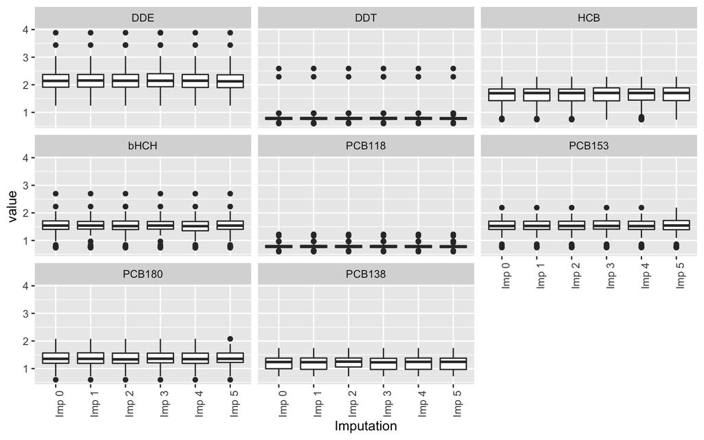

```r
plotFamily(ex_imp, family = "Organochlorines")
```

For categorical exposures, the method draws accumulated bar-plot:

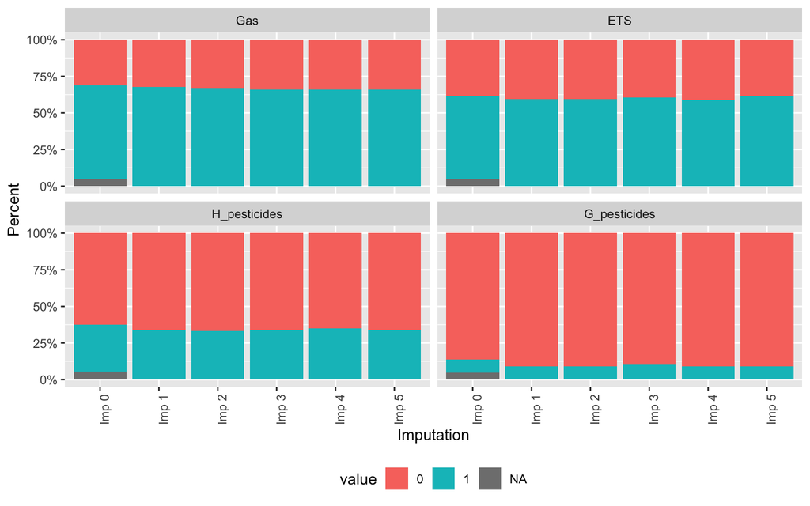

```r
plotFamily(ex_imp, family = "Home Environment")
```

The arguments `group` and `na.omit` are not available when `plotFamily` is used with an `imExposomeSet`.

## 1.4 Extracting an `ExposomeSet` from an `imExposomeSet`

Once an `imExposomeSet` is created, an `ExposomeSet` can be obtained by selecting one of the internal imputed-sets. This is done using the method `toES` and setting the argument `rid` with the number of the imputed-set to use:

```r
ex_1 <- toES(ex_imp, rid = 1)
ex_1
```

```
## Object of class 'ExposomeSet' (storageMode: environment)
##  . exposures description:
##     . categorical:  4
##     . continuous:  43
##  . exposures transformation:
##     . categorical: 0
##     . transformed: 0
##     . standardized: 0
##     . imputed: 0
##  . assayData: 47 exposures 109 individuals
##     . element names: exp
##     . exposures: AbsPM25, ..., Temp
##     . individuals: 1, ..., 98
##  . phenoData: 109 individuals 10 phenotypes
##     . individuals: 1, ..., 98
##     . phenotypes: whistling_chest, ..., .imp.1
##  . featureData: 47 exposures 8 explanations
##     . exposures: AbsPM25, ..., Temp
##     . descriptions: Family, ..., .imp
## experimentData: use 'experimentData(object)'
## Annotation:
```

```r
ex_3 <- toES(ex_imp, rid = 3)
ex_3
```

```
## Object of class 'ExposomeSet' (storageMode: environment)
##  . exposures description:
##     . categorical:  4
##     . continuous:  43
##  . exposures transformation:
##     . categorical: 0
##     . transformed: 0
##     . standardized: 0
##     . imputed: 0
##  . assayData: 47 exposures 109 individuals
##     . element names: exp
##     . exposures: AbsPM25, ..., Temp
##     . individuals: 1, ..., 98
##  . phenoData: 109 individuals 10 phenotypes
##     . individuals: 1, ..., 98
##     . phenotypes: whistling_chest, ..., .imp.1
##  . featureData: 47 exposures 8 explanations
##     . exposures: AbsPM25, ..., Temp
##     . descriptions: Family, ..., .imp
## experimentData: use 'experimentData(object)'
## Annotation:
```

# 2 Exposome-Wide Association Studies (ExWAS)

The interesting point on working with multiple imputations is to test the association of the different version of the exposures with a target phenotype. `rexposome` implements the method `exwas` to be used with an `imExposomeSet`.

```r
as_iew <- exwas(ex_imp, formula = blood_pre~sex+age, family = "gaussian")
as_iew
```

```
## An object of class 'ExWAS'
##
##        blood_pre ~ sex+age
##
## Tested exposures:  47
## Threshold for effective tests (TEF):  2.44e-03
##  . Tests < TEF: NA
```

As usual, the object obtained from `exwas` method can be plotted using `plotExwas`:

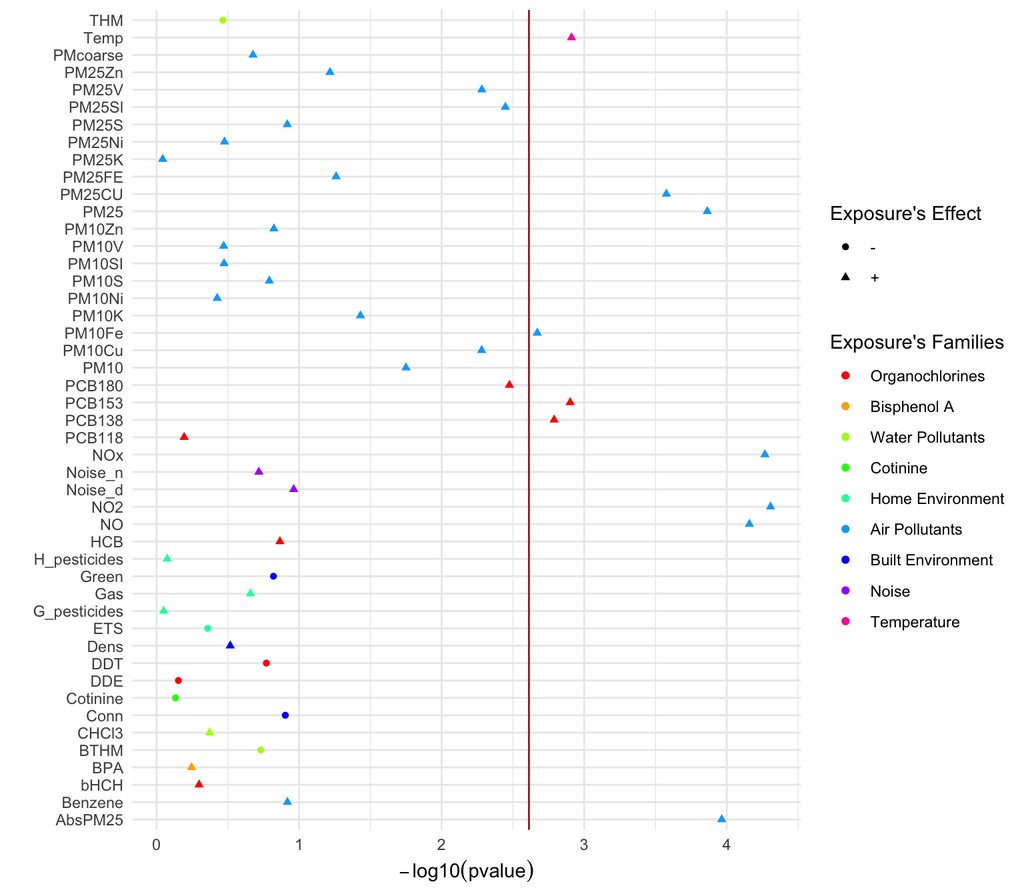

```r
clr <- rainbow(length(familyNames(ex_imp)))
names(clr) <- familyNames(ex_imp)
plotExwas(as_iew, color = clr)
```

## 2.1 Extract the exposures over the *threshold of effective tests*

The method `extract` allows to obtain a table of P-Values from an `ExWAS` object. At the same time, the `tef` method allows to obtain the *threshold of effective tests* computed at `exwas`. We can use them combined in order to create a table with the P-Value of the exposures that are beyond the *threshold of efective tests*.

1. First we get the *threshold of effective tests*

```r
(thr <- tef(as_iew))
```

```
## [1] 0.002441308
```

2. Second we get the table of P-Values

```r
tbl <- extract(as_iew)
```

3. Third we filter the table with the threshold

```r
(sig <- tbl[tbl$pvalue <= thr, ])
```

```
## DataFrame with 10 rows and 4 columns
##                       pvalue           effect             X2.5
##                    <numeric>        <numeric>        <numeric>
## NO2     4.93174209856839e-05 15.1019393592132 8.05249677475728
## NOx      5.4053184695313e-05 13.0679142694299  6.9237273749917
## NO      6.93577244148535e-05 10.4612167216436  5.4675489250452
## AbsPM25  0.00010849521186973 19.6283472511496 9.96133403024455
## PM25    0.000137011348647853 36.8364649364314 18.4399075002739
## PM25CU  0.000265183311340955 11.7686204802454 5.60126881235511
## Temp     0.00122705664499012 88.1527135282858 35.5988388431556
## PCB153   0.00125475824499421 4.26293143314533 1.71426970647294
## PCB138   0.00162516166610449 4.64231172123763 1.79535492687626
## PM10Fe   0.00213657460974703 13.4582118778229 4.99484009546175
##                    X97.5
##                <numeric>
## NO2     22.1513819436691
## NOx     19.2121011638681
## NO      15.4548845182419
## AbsPM25 29.2953604720547
## PM25    55.2330223725888
## PM25CU  17.9359721481356
## Temp    140.706588213416
## PCB153  6.81159315981772
## PCB138  7.48926851559899
## PM10Fe  21.9215836601841
```